# Enterprise Analytics Automation System

Reproducible R + Quarto Infrastructure for Data Cleaning, Statistical Modeling, Visual Diagnostics, and Automated Reporting

Author

Dr. Carter | Quantitative Methodology & Analytics Automation Consultant

## I Build Reproducible Analytics Systems That Replace Manual Reporting Workflows

This project is a working proof-of-capability: a modular R and Quarto system that cleans data, validates records, runs statistical summaries, generates diagnostic figures, and compiles the results into a client-facing HTML report.

The goal is not a one-off dashboard. The goal is a repeatable analytic system that can be rerun, inspected, modified, documented, and scaled.

For clients, this means fewer manual spreadsheet errors, faster reporting cycles, cleaner technical documentation, and outputs that are easier to audit, explain, and trust.

## What This System Demonstrates

**Automated data preparation**  
Raw records are generated or ingested programmatically, filtered through scripted rules, cleaned, transformed, and prepared for analysis.

**Reproducible statistical reporting**  
Analytic summaries and visual diagnostics are generated through reusable R functions rather than manual spreadsheet manipulation.

**Client-facing Quarto output**  
The workflow compiles results into an HTML report that can be shared as a webpage, portfolio artifact, internal report, or recurring client deliverable.

**Scalable processing logic**  
The advanced processing module demonstrates parallelized batch execution, seeded simulation runs, error-catching, aggregation, and diagnostic telemetry.

## Pipeline Architecture

**1. Data Layer**  
Raw or simulated operational data enter the workflow through a scripted ingestion layer.

**2. Cleaning and Validation Layer**  
The pipeline filters invalid records, standardizes variables, handles anomalous values, and creates derived metrics.

**3. Modeling Layer**  
Reusable R functions summarize behavioral or operational patterns across groups, timepoints, or client-defined segments.

**4. Diagnostic Layer**  
The workflow exports publication-quality visual diagnostics into the project structure.

**5. Reporting Layer**  
A master automation script renders the Quarto source document into a polished HTML report.

## Automated Data Cleaning and Integrity Audit

The first module simulates an incoming operational dataset, removes missing segment records, standardizes segment labels, handles anomalous values, and creates a derived longitudinal change metric. This is the kind of scripted cleaning layer that replaces fragile manual spreadsheet cleanup.

| user_id | segment | baseline_engagement | q1_activity | q2_activity | variance_delta |
| --- | --- | --- | --- | --- | --- |
| 1002 | Mid-Market | 49.08743639910224 | 28.83656416921461 | 71.02097665030036 | 42.18441248108574 |
| 1003 | SMB | 53.99959374815337 | 57.37157861952835 | 51.36407325967637 | -6.007505359851983 |
| 1004 | Enterprise | 55.88901656549108 | 78.07021241435868 | 16.9521624803683 | -61.11804993399038 |
| 1005 | Enterprise | 49.83121960613187 | 43.86256059871874 | 63.38469400920449 | 19.52213341048575 |
| 1006 | SMB | 54.18704182088633 | 51.0521932874938 | 42.76883956539426 | -8.283353722099541 |
| 1007 | Mid-Market | 58.00727964524837 | 66.42485803660298 | 59.95822396093496 | -6.466634075668026 |
| 1008 | Enterprise | 56.79893103827864 | 74.72960620165416 | 53.40192433482311 | -21.32768186683106 |
| 1009 | SMB | 63.09663922539539 | 45.83147884632174 | 37.46929444205333 | -8.362184404268412 |
| 1010 | Enterprise | 31.08785521130919 | 48.63671111191649 | 61.62291177303975 | 12.98620066112326 |
| 1011 | SMB | 53.44907334668953 | 33.81254620957836 | 45.46928391736967 | 11.65673770779131 |

[output cut: 4449 more lines]

## Statistical Modeling and Segment-Level Diagnostics

The second module summarizes baseline engagement, state-level activity, and longitudinal volatility across operational segments. This translates cleaned data into interpretable client-facing metrics.

| segment | Mean_Baseline | Mean_Q1_State | Mean_Q2_State | Volatility_Index |
| --- | --- | --- | --- | --- |
| Enterprise | 49.49490628594232 | 54.80214359046398 | 47.7322723082427 | 19.25784383532334 |
| Mid-Market | 49.8129307407503 | 54.94432532430569 | 48.15685238523637 | 18.95014605023865 |
| SMB | 50.53870000518736 | 55.23314732319467 | 48.48570429620965 | 19.20714212373016 |

## Longitudinal Structural Drift

This diagnostic isolates the change from Q1 to Q2 within each segment. In a client setting, the same structure could be adapted to track customer behavior, program outcomes, survey movement, retention risk, operational performance, or repeated-measures research outcomes.

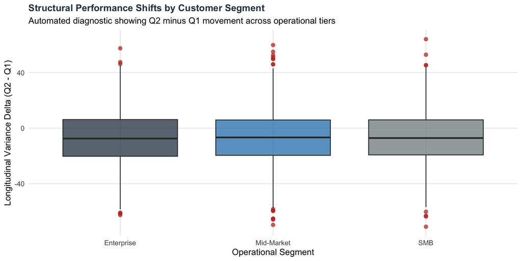

## Technical Validation and Scalable Processing Telemetry

This section demonstrates the advanced processing layer: parallelized batch execution, seeded simulation runs, matrix inversion checks, error handling, and aggregation into a final diagnostic object. The point is to show scalable analytic architecture, not just a static report.

```
  batch condition_index   determinant failure_flag
1     1       1913361.1 1.047576e+157        FALSE
2     2      43659541.2 2.682549e+152        FALSE
3     3        749881.7 4.674348e+155        FALSE
4     4        642184.9 7.817267e+157        FALSE
5     5       1735766.8 1.199690e+155        FALSE
6     6     312574809.6 4.442663e+152        FALSE
```

### Numerical Stability Analysis

The scaling module tracks matrix condition numbers across batch runs. In production analytics, this kind of diagnostic layer can help distinguish ordinary computational variation from true pipeline failures or mathematically unstable transformations.

| batch | condition_index | determinant | failure_flag |
| --- | --- | --- | --- |
| 1 | 1913361.138513867 | 1.047575999617595e+157 | False |
| 2 | 43659541.21864405 | 2.682549383942741e+152 | False |
| 3 | 749881.7132002682 | 4.674347589868419e+155 | False |
| 4 | 642184.9296839599 | 7.817267423401792e+157 | False |
| 5 | 1735766.830303908 | 1.199690473625616e+155 | False |
| 6 | 312574809.5560507 | 4.442663030772723e+152 | False |
| 7 | 614108.775715397 | 2.221233586933707e+155 | False |
| 8 | 28301185.86706242 | 1.742339631145977e+156 | False |
| 9 | 198189.4274487087 | 7.117176009312123e+156 | False |
| 10 | 339901.7773598834 | 5.073010318497197e+152 | False |

[output cut: 90 more lines]

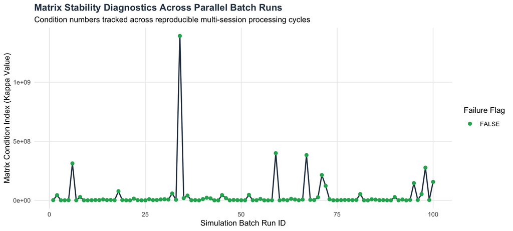

## Executive Interpretation

This demonstration shows how a manual reporting process can be converted into a reproducible analytics system.

**Data integrity:** The workflow applies scripted cleaning rules rather than relying on manual spreadsheet edits.

**Analytic reproducibility:** Statistical summaries and visual diagnostics are generated from reusable functions, making the workflow easier to rerun, audit, and modify.

**Reporting automation:** The final HTML report is generated from Quarto, allowing the same pipeline to support web reports, PDF reports, internal documentation, or recurring client deliverables.

**Scalability:** The advanced processing layer demonstrates parallel execution, seeded batch processing, error-catching, and diagnostic aggregation for larger computational workflows.

## Client Applications

This architecture can be adapted for:

- automated weekly or monthly reporting
- survey analysis dashboards
- research lab reporting systems
- nonprofit impact reporting
- business KPI summaries
- data quality audits
- reproducible statistical reports
- executive-facing HTML or PDF reports
- replacing fragile Excel workflows with scripted R/Quarto pipelines

## Consulting Services

I build reproducible analytics systems for researchers, businesses, nonprofits, and teams that need reliable reporting instead of fragile manual workflows.

Typical projects include:

- converting manual Excel reporting into automated R/Quarto workflows
- cleaning and validating messy survey, research, or business datasets
- building reproducible statistical analysis reports
- creating automated HTML, PDF, or presentation-ready outputs
- developing reusable reporting templates for recurring projects
- auditing existing data workflows for errors, inefficiency, and reproducibility problems
- translating complex statistical results into client-facing reports

## Technical Stack

**Core tools:** R, Quarto, ggplot2, dplyr, DT, future, future.apply  
**Workflow type:** reproducible analytics pipeline  
**Output type:** client-facing HTML report  
**Primary value:** automated analysis, validated reporting, reproducible documentation, and scalable workflow design